# Cost of Living Analysis

Soumya Pannala

## Introduction

**Reason for Interest:** There are good and bad aspects to every country, ranging from safety to scenery. However, when considering moving to another country or operating a foreign business, money makes the first case. Evaluating what makes financial sense often precedes comparing the other factors that define a country. As such, a Cost of Living Analysis has real-world applications, allowing you to see the relationships between cost of living, average monthly income, and average individual tax rates across different countries and regions. Additionally, by creating a color-coded map and other visualizations, it will be easy to see which countries are most favorable in terms of finances. This analysis will serve as an informative resource for those engaging in foreign business planning or simply for individuals planning to relocate.

**Importance:** A country’s cost of living determines how much income individuals need to cover basic expenses and it directly influences the amount of disposable income left over after essential spending. Countries vary widely in their cost of living due to differences in the price of basic necessities, such as housing, food, transportation, healthcare, education, and taxes. Understanding these variations is valuable for comparing economic conditions across countries, evaluating salary levels, identifying trends in affordability over time, and exploring how income, taxation, and savings interact to shape overall quality of life.

## Questions of Interest

1. What are the top ten financially favorable countries in terms of cost of living?
2. What are the trends over the years in terms of lowering cost of living?
3. How does cost of living differ across regions?
4. Are countries with lower costs of living characterized by higher savings percentages and average monthly incomes?
5. Are countries with lower costs of living also characterized by lower or higher tax rates? And are tax rates responsible for the variation in average monthly income and savings percentages unexplained by cost of living alone?
6. What contributes greatest to a country’s cost of living? Is it healthcare, education, transportation, or housing? Or are they all roughly equal?

## About the Data

For this analysis, we will be using three separate datasets all found on Kaggle. The first is an extended Cost of Living Dataset for Countries while the second covers Cost of Living for Cities. Although the third dataset is solely focused on the year 2022, it has far more countries than the first dataset (Extended Cost of Living for Countries), adding useful information for a couple analyses when used in conjunction with the first two datasets.

The datasets have slight variations in the variables they use and their sizes so I have summarized each below:

1. **Regional Cost of Living Dataset:** https://www.kaggle.com/datasets/heidarmirhajisadati/regional-cost-of-living-analysis
   - **Filename:** Cost_of_Living_and_Income_Extended.csv
   - **Size:** 500 rows x 11 columns
   - **Variable Descriptions:**  
     **Country:** The name of the country where the data was recorded.  
     **Region:** The geographical region to which the country belongs (e.g., Asia, Europe).  
     **Year:** The year when the data was recorded.  
     **Average_Monthly_Income:** The average monthly income of individuals in USD.  
     **Cost_of_Living:** The average monthly cost of living in USD, including essentials like housing, food, and utilities.  
     **Housing_Cost_Percentage:** The percentage of income spent on housing expenses.  
     **Tax_Rate:** The average tax rate applied to individuals’ income, expressed as a percentage.  
     **Savings_Percentage:** The portion of income saved monthly, expressed as a percentage.  
     **Healthcare_Cost_Percentage:** The percentage of income spent on healthcare services.  
     **Education_Cost_Percentage:** The percentage of income allocated to educational expenses.  
     **Transportation_Cost_Percentage:** The percentage of income spent on transportation costs.
2. **Cost of Living Index by Cities:** https://www.kaggle.com/datasets/debdutta/cost-of-living-index-by-country
   - **Filename:** Cost_of_living_index.csv
   - **Size:** 536 rows x 10 columns
   - **Variable Descriptions:**

     **City:** Includes city and country, and sometimes state if the country is the United States.  
     **Cost of Living Index (Excluding Rent):** Cost of living indices are relative to New York City (NYC) which means that for New York City, each index should be 100. If another city has, for example, rent index of 120, it means that on an average in that city rents are 20% more expensive than in New York City. This is a relative indicator of consumer goods prices, including groceries, restaurants, transportation and utilities.  
     **Rent Index**: is an estimation of prices of renting apartments in the city compared to New York City. If Rent index is 80, Numbeo estimates that price of rents in that city is on an average 20% less than the price in New York.  
     **Groceries Index:** is an estimation of grocery prices in the city compared to New York City. To calculate this section, Numbeo uses weights of items in the “Markets” section for each city.  
     **Restaurants Index**: is a comparison of prices of meals and drinks in restaurants and bars compared to NYC.  
     **Cost of Living Plus Rent Index**: is an estimation of consumer goods prices including rent comparing to New York City.  
     **Local Purchasing Power**: shows relative purchasing power in buying goods and services in a given city for the average wage in that city. If domestic purchasing power is 40, this means that the inhabitants of that city with the average salary can afford to buy on an average 60% less goods and services than New York City residents with an average salary.
3. **Cost of Living Index 2022:** https://www.kaggle.com/datasets/ankanhore545/cost-of-living-index-2022
   - **Filename:** Cost_of_Living_Index_2022.csv
   - **Size:** 139 rows x 9 columns
   - **Variable Descriptions:** The variables in this dataset are mostly the same as those in the Cost of Living Index by Cities dataset. The variables include, `country`, `cost_of_living_index`, `rent_index`, `cost_of_living plus rent`**,** `groceries_index`, `restaurant_price_index`, and `local_purchasing_power`.

Before we begin by reading in our data, let’s read in all the packages we will be using during our analysis.

### Loading Packages

```r
library(tidyverse)
library(readr)
library(janitor)
library(tidyr)
library(ggplot2)
library(dplyr)
library(patchwork)
library(maps)
library(countrycode)
library(viridis)
```

### Reading in Data

```r
countryCOL <- read_csv("C:\\Users\\soumy\\Desktop\\MyStuff\\NCSU\\Fall 2025\\BAE 555 - 601\\Final Project Files\\Cost_of_Living_and_Income_Extended.csv")

cityCOL <- read_csv("C:\\Users\\soumy\\Desktop\\MyStuff\\NCSU\\Fall 2025\\BAE 555 - 601\\Final Project Files\\Cost_of_living_index.csv")

COL2022 <- read_csv("C:\\Users\\soumy\\Desktop\\MyStuff\\NCSU\\Fall 2025\\BAE 555 - 601\\Final Project Files\\Cost_of_Living_Index_2022.csv")
```

## Data Cleaning and Wrangling

Here, we start by cleaning names and converting variables to factor for the `countryCOL` dataset.

```r
countryCOL <- clean_names(countryCOL)

countryCOL$region <- as.factor(countryCOL$region)
countryCOL$country <- as.factor(countryCOL$country)
countryCOL$year <- as.factor(countryCOL$year)

countryCOL
```

```
# A tibble: 500 × 11
   country    year  average_monthly_income cost_of_living housing_cost_percent…¹
   <fct>      <fct>                  <dbl>          <dbl>                  <dbl>
 1 Australia  2013                   3484.          1106.                   32.1
 2 India      2019                   7771.          5423.                   25.2
 3 Russia     2004                   6991.          3972.                   40.8
 4 South Afr… 2011                   6628.          6756.                   30.4
 5 Brazil     2015                   2434.          2656.                   49.3
 6 Australia  2015                   1782.          4575.                   39.2
 7 China      2020                   5515.          6551.                   44.7
 8 Japan      2006                   7470.          1077.                   24.0
 9 Australia  2003                   4676.          6586.                   45.9
10 Russia     2000                   4787.          4940.                   47.7
# ℹ 490 more rows
# ℹ abbreviated name: ¹housing_cost_percentage
# ℹ 6 more variables: tax_rate <dbl>, savings_percentage <dbl>,
#   healthcare_cost_percentage <dbl>, education_cost_percentage <dbl>,
#   transportation_cost_percentage <dbl>, region <fct>
```

Now, we’ll continue with the next dataset, cleaning names, separating `city` into 3 columns, and converting the 3 columns to factor for the `cityCOL` dataset.

```r
cityCOL <- clean_names(cityCOL)

cityCOL <- cityCOL %>%
  separate(city, c("city", "state_country"), sep = ", ", extra = "merge")

cityCOL <- cityCOL %>%
  separate(state_country, c("state", "country"), sep = ", ", fill = "left")

cityCOL$city <- as.factor(cityCOL$city)
cityCOL$state <- as.factor(cityCOL$state)
cityCOL$country <- as.factor(cityCOL$country)

cityCOL
```

```
# A tibble: 536 × 10
    rank city      state country     cost_of_living_index rent_index
   <dbl> <fct>     <fct> <fct>                      <dbl>      <dbl>
 1     1 Hamilton  <NA>  Bermuda                     138.      103.
 2     2 Zurich    <NA>  Switzerland                 129.       62.6
 3     3 Basel     <NA>  Switzerland                 127.       46.1
 4     4 Lausanne  <NA>  Switzerland                 120.       50.4
 5     5 Bern      <NA>  Switzerland                 118.       39.2
 6     6 Geneva    <NA>  Switzerland                 118.       69.2
 7     7 Reykjavik <NA>  Iceland                     113.       57.4
 8     8 Lugano    <NA>  Switzerland                 112.       49.6
 9     9 Stavanger <NA>  Norway                      111        38.8
10    10 Oslo      <NA>  Norway                      107.       48.6
# ℹ 526 more rows
# ℹ 4 more variables: cost_of_living_plus_rent_index <dbl>,
#   groceries_index <dbl>, restaurant_price_index <dbl>,
#   local_purchasing_power_index <dbl>
```

Let’s finish by cleaning names and converting variables to factor for the `COL2022` dataset as well.

```r
COL2022 <- clean_names(COL2022)

COL2022$country <- as.factor(COL2022$country)

COL2022 <- COL2022 %>% mutate(year = 2022)

COL2022$year <- as.factor(COL2022$year)

COL2022
```

```
# A tibble: 139 × 9
    rank country     cost_of_living_index rent_index cost_of_living_plus_rent_…¹
   <dbl> <fct>                      <dbl>      <dbl>                       <dbl>
 1     1 Afghanistan                 20.4       2.72                        12.1
 2     2 Albania                     35.5       8.47                        22.8
 3     3 Algeria                     26.9       4.59                        16.4
 4     4 Argentina                   34.7       7.71                        22.0
 5     5 Armenia                     33.9      11.6                         23.4
 6     6 Australia                   77.8      36.8                         58.6
 7     7 Austria                     71.0      27.1                         50.5
 8     8 Azerbaijan                  29.7       7.86                        19.5
 9     9 Bahamas                     84        35.3                         61.2
10    10 Bahrain                     54.8      29.2                         42.8
# ℹ 129 more rows
# ℹ abbreviated name: ¹cost_of_living_plus_rent_index
# ℹ 4 more variables: groceries_index <dbl>, restaurant_price_index <dbl>,
#   local_purchasing_power_index <dbl>, year <fct>
```

## Exploratory Data Analysis (EDA) & Visualization

Before we dive into the questions of interest, let’s start by creating a world map color-coded by `cost_of_living` so that we can start making and revising some initial predictions. Additionally, this map will give us an idea of what countries provide favorable cost conditions for various purposes, so that we can keep these ideal countries in mind as we continue through the analysis. This might lead us to understand which are truly ideal, as we want not only lower cost of living, but also favorable tax rates, savings percentages, average monthly incomes, and more. In other words, if a country has a low cost of living but a high tax rate, leaving us with less disposable income, impacting our ability to save as much as we would like, it would not truly be a financially favorable country.

First, we need to get world map data.

```r
world_map <- map_data("world")
```

Now, we have to join our data with world map data.

```r
chloropleth <- world_map %>% left_join(COL2022, by = c("region" = "country"))
```

Now we can create the chloropleth map

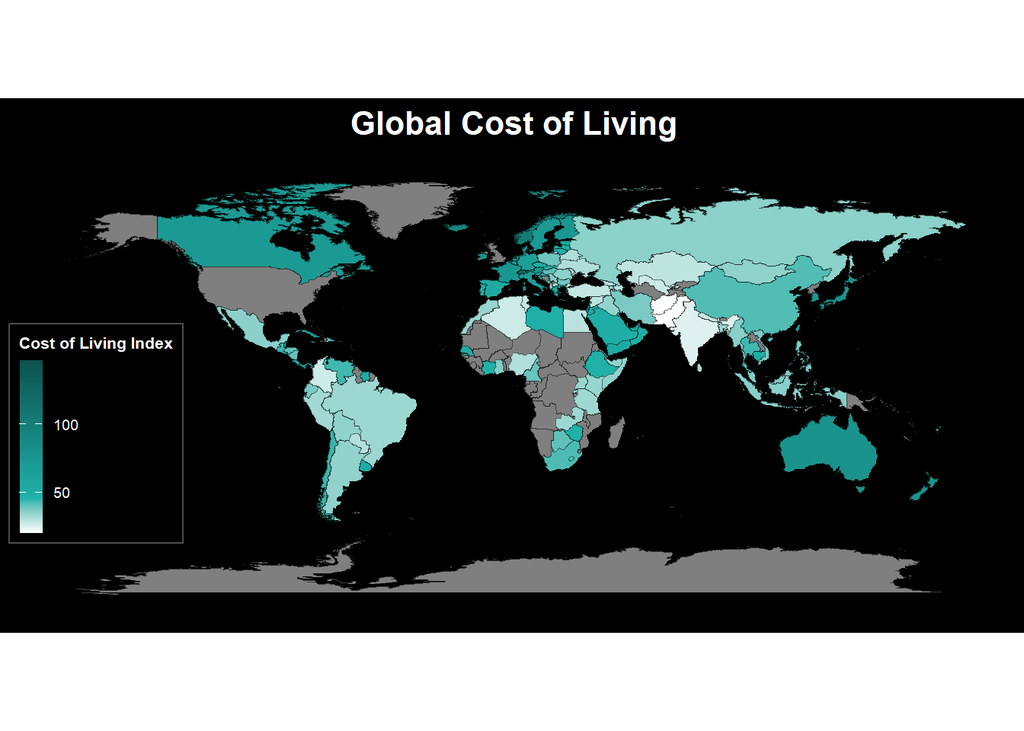

```r
j <- ggplot(chloropleth, aes(long, lat, group = group)) +
  geom_polygon(aes(fill = cost_of_living_index),
               color = alpha("black", 1/2),
               size = 0.2) +
  coord_fixed() +
  theme_minimal() +
  labs(title = "Global Cost of Living") +
  scale_fill_gradientn(
    colors = c("white", "lightseagreen", "#1B9A93", "#16827C", "#116A65","#0C524E"),
    name = "Cost of Living Index") +
  theme( plot.background = element_rect(fill = "black", color = "black"),
         panel.background = element_rect(fill = "black", color = "black"),
         panel.grid = element_blank(),
         plot.title = element_text( color = "white", size = 16, face = "bold",
                                    hjust = 0.5, margin = margin(b = 10) ),
         legend.position = c(0.08, 0.4),
         legend.background = element_rect(fill = "black", color = "gray30"),
         legend.text = element_text(color = "white", size = 7),
         legend.title = element_text(color = "white", size = 8, face = "bold"),
         legend.key.height = unit(0.6, "cm"),
         legend.key.width = unit(0.4, "cm"),
         legend.margin = margin(5, 5, 5, 5),
         axis.line = element_blank(),
         axis.text = element_blank(),
         axis.ticks = element_blank(),
         axis.title = element_blank()
         )
j
```

```r
ggsave("Cost_of_Living_Map.pdf")
```

As we look at this map, we must keep in mind that this is for the **year 2022**, since we are using the `COL2022` dataset. This dataset simply covers more countries, so even though it is not 2025 data, it should be reasonably close to 2025 values for the majority of the countries as these things don’t change too drastically unless there is a significant economic event, such as COVID back in 2019, which may have caused changes in `cost_of_living` for many countries.

With this map, we can understand at a glance that certain countries and regions have lower costs of living with the southern tip of Asia having the lowest costs of living. Other than China, the eastern part of Europe and Asia seem to have lower costs of living. South America and Mexico also have fairly low cost of living levels. If people plan to relocate or operate a foreign business, choosing these countries might be financially savvy, provided that tax rates in these entities, not to mention several other important factors, are also favorable.

### Question 1: What are the top ten financially favorable countries in terms of cost of living?

Although we could use the `countryCOL` dataset, allowing us to compare `cost_of_living` and `tax_rate` side by side, the `COL2022` dataset has many more countries giving us a better idea of which countries are favorable based on `cost_of_living`. With this information, if there is a certain country of interest to anyone planning to engage with the foreign country in any way, they could find current tax rates and see if it is still favorable for their income levels.

To still allow some comparison, I have created a second plot using the `country_COL` dataset showing the tax rates for available countries in 2022. This could at least help weed out some countries that are favorable by `cost_of_living` but unfavorable by `tax_rate`.

This must all be interpreted in context of your purposes, though. If you are planning to relocate, you want low `cost_of_living` and low `tax_rate`. However, with foreign business planning, sometimes having low `cost_of_living` but high `tax_rate` can help when trying to take deductions, and in some cases, you can always keep your business in that country, and, when applicable, shift income to a lower_tax jurisdiction in an arm’s length transaction if you have multiple branches of your business in different countries.

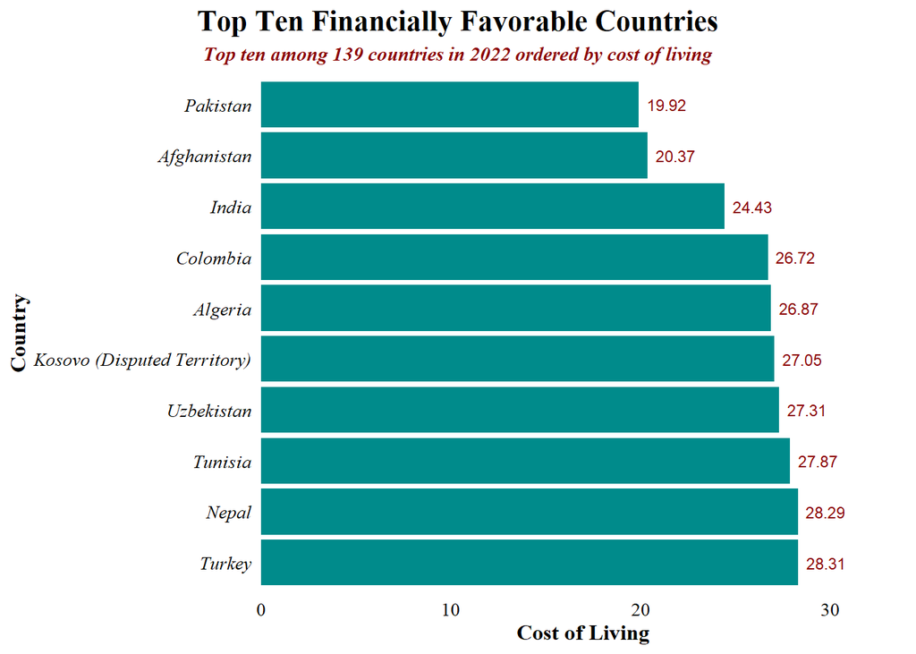

```r
g <- COL2022 %>%
  arrange(cost_of_living_index) %>%
  head(10) %>%
  ggplot(aes(x = cost_of_living_index,
             y = fct_rev(fct_reorder(country, cost_of_living_index)))) +
  geom_bar(stat = "identity", fill = "darkcyan") +
  geom_text(aes(label = cost_of_living_index),
            hjust = -0.2, size = 3, color = "#8B0000") +
  labs(title = "Top Ten Financially Favorable Countries",
       subtitle = "Top ten among 139 countries in 2022 ordered by cost of living",
       x = "Cost of Living", y = "Country") +
  scale_x_continuous(expand = expansion(mult = c(0, 0.2))) +
  theme_minimal() +
  theme( text = element_text(family = "serif"),
         plot.title = element_text(size = 16,
                                   face = "bold",
                                   color = "black",
                                   hjust = 0.5),
         plot.subtitle = element_text(face = "bold.italic",
                                      color = "#8B0000",
                                      hjust = 0.5),
         axis.title = element_text(size = 12,
                                   face = "bold",
                                   color = "black"),
         axis.text = element_text(size = 10,
                                  color = "black"),
         axis.text.y = element_text(face = "italic"),
         panel.grid.major = element_blank(),
         panel.grid.minor = element_blank(),
         plot.title.position = "plot" )
g
```

```r
ggsave("Top_Ten_Countries_for_Cost_of_Living.pdf")
```

This plot shows that the top ten favorable countries are scattered in many regions, including Asia, Africa, and South America. Now let’s see how examining tax rates can inform our perception of these ten as financially favorable.

Now for the comparison plot, let’s get only 2022 data from `countryCOL` and create a summary of average tax rate to ensure that we only have one `tax_rate` value per `country` for `2022`.

```r
tax_rates_2022 <- countryCOL %>%
  select("country", "year", "tax_rate") %>%
  filter(year == 2022) %>%
  group_by(country) %>%
  summarize(avg_tax_rate = mean(tax_rate))

tax_rates_2022
```

```
# A tibble: 10 × 2
   country       avg_tax_rate
   <fct>                <dbl>
 1 Brazil                19.3
 2 Canada                19.7
 3 China                 26.7
 4 France                25.2
 5 Germany               34.5
 6 India                 38.6
 7 Japan                 27.8
 8 Mexico                25.0
 9 South Africa          24.2
10 United States         12.6
```

Since we only have ten values in total, let’s plot them all in order from lowest to highest and see what we can glean from this plot when analyzed in conjunction with the previous two.

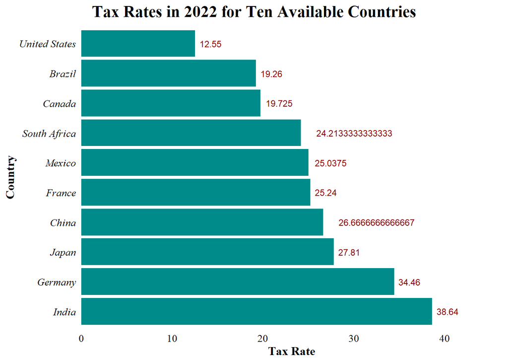

```r
g <- tax_rates_2022 %>%
  arrange(avg_tax_rate) %>%
  head(10) %>%
  ggplot(aes(x = avg_tax_rate,
             y = fct_rev(fct_reorder(country, avg_tax_rate)))) +
  geom_bar(stat = "identity", fill = "darkcyan") +
  geom_text(aes(label = avg_tax_rate),
            hjust = -0.2, size = 3, color = "#8B0000") +
  labs(title = "Tax Rates in 2022 for Ten Available Countries",
       x = "Tax Rate", y = "Country") +
  scale_x_continuous(expand = expansion(mult = c(0, 0.2))) +
  theme_minimal() +
  theme( text = element_text(family = "serif"),
         plot.title = element_text(size = 16,
                                   face = "bold",
                                   color = "black",
                                   hjust = 0.5),
         axis.title = element_text(size = 12,
                                   face = "bold",
                                   color = "black"),
         axis.text = element_text(size = 10,
                                  color = "black"),
         axis.text.y = element_text(face = "italic"),
         panel.grid.major = element_blank(),
         panel.grid.minor = element_blank(),
         plot.title.position = "plot" )
g
```

```r
ggsave("All_Ten_Countries_for_Tax_Rates.pdf")
```

Notice here that the only country that is present in both plots is India. While it had a low `cost_of_living`, it has a pretty high `tax_rate`. This could be a good jurisdiction for a branch of your business so that you can get more in deductions, but it may not be the best prospect based on your level of income. While the other countries are not also present in the previous plot, which showed only the top ten in `cost_of_living`, we can still tease out the countries that are reasonably favorable on both fronts using the map we first created. For example, Canada has a high `cost_of_living` but lower `tax_rate`. Brazil, on the other hand, is more favorable with a reasonably low `cost_of_living` and low `tax_rate`.

### Question 2: What are the trends over the years in terms of lowering cost of living?

First, let’s create a summary so that we only get one value for `cost_of_living`, `average_monthly_income`, and `savings_percentage` per `country` per `year`. I left in all the other variables so that we can reuse our summary for some of the later questions as well.

```r
countryCOL_summary <- countryCOL %>%
  group_by(country, year) %>%
  summarise(cost_of_living = mean(cost_of_living, na.rm = TRUE),
    average_monthly_income = mean(average_monthly_income, na.rm = TRUE),
    savings_percentage = mean(savings_percentage, na.rm = TRUE),
    tax_rate,
    housing_cost_percentage,
    healthcare_cost_percentage,
    education_cost_percentage,
    transportation_cost_percentage,
    region) %>%
  ungroup()
```

Before we create the plot, we should create a threshold level and use that to create a new variable that we can use to color-code points based on the relative levels of `cost_of_living` (`high` or `low`).

```r
threshold <- median(countryCOL_summary$cost_of_living, na.rm = TRUE)

countryCOL_summary <- countryCOL_summary %>%
  mutate(level = ifelse(cost_of_living > threshold, "High", "Low"))
```

Now we can create a faceted plot by `country` so that we can see the trends for each `country` over the years from `2000` to `2025`.

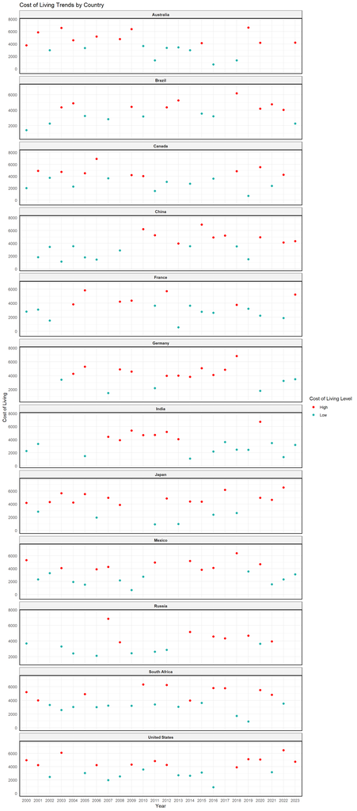

```r
h <- ggplot(countryCOL_summary, aes(x = year, y = cost_of_living, color = level)) +
  geom_point(size = 2) +
  facet_wrap(~ country, ncol = 1, scales = "free_y") +
  scale_color_manual(values = c("High" = "red", "Low" = "lightseagreen")) +
  scale_y_continuous(expand = expansion(mult = c(0.25, 0.25))) +
  labs(title = "Cost of Living Trends by Country",
    x = "Year",
    y = "Cost of Living",
    color = "Cost of Living Level") +
  theme_minimal() +
  theme(panel.border = element_rect(color = "black", fill = NA, linewidth = 1),
    strip.background = element_rect(fill = "grey95", color = "black"),
    strip.text = element_text(face = "bold"))
h
```

```r
ggsave("Cost_of_Living_Trends.pdf")
```

We saw earlier that `Brazil`, `Canada`, and the `United States` all had favorable tax rates as of `2022`. But when we look at their current `cost_of_living` values, only `Brazil` is favorable of the three countries. Besides `Brazil`, `Germany`, `Mexico`, `India`, and `South Africa` all have low `cost_of_living` values. Another pattern we can notice is that several countries experienced an increase in `cost_of_living` in `2019` or `2020` based on how soon the COVID pandemic reached that particular country. Notably, `Australia`, `Brazil`, `France`, `Germany`, and `Russia` saw decreases in `cost_of_living` around the time of the COVID pandemic.

### Question 3: How does cost of living differ across regions?

We noticed earlier when looking at the map that some countries with lower `cost_of_living` levels were clustered together, but is there a regional pattern? To check, let’s create a series of boxplots that show us how the regions compare. Before we do this, we’ll have to use the `countrycode` package we loaded in earlier. This package contains `country` and `region` variables. Since our `COL2022` dataset has `country` but not `region`, we can use this package to add a new `region` variable using its specified mapping.

```r
COL2022_summary <- COL2022 %>%
  group_by(country) %>%
  summarise(cost_of_living = mean(cost_of_living_index, na.rm = TRUE)) %>%
              mutate(region = countrycode(sourcevar = country,
                              origin = "country.name",
                              destination = "region"))

COL2022_summary$region <- as.factor(COL2022_summary$region)

COL2022_summary
```

```
# A tibble: 139 × 3
   country     cost_of_living region
   <fct>                <dbl> <fct>
 1 Afghanistan           20.4 South Asia
 2 Albania               35.5 Europe & Central Asia
 3 Algeria               26.9 Middle East & North Africa
 4 Argentina             34.7 Latin America & Caribbean
 5 Armenia               33.9 Europe & Central Asia
 6 Australia             77.8 East Asia & Pacific
 7 Austria               71.0 Europe & Central Asia
 8 Azerbaijan            29.7 Europe & Central Asia
 9 Bahamas               84   Latin America & Caribbean
10 Bahrain               54.8 Middle East & North Africa
# ℹ 129 more rows
```

Now, let’s create the boxplots and see if we can conclude any patterns.

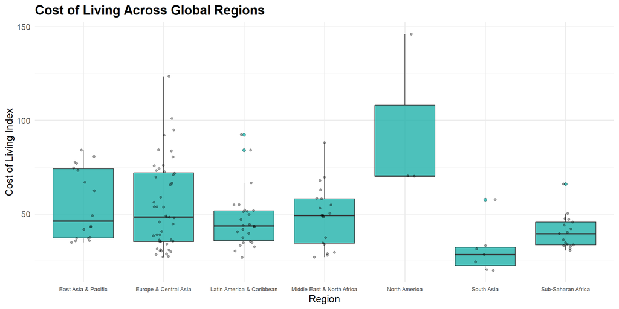

```r
ggplot(COL2022_summary, aes(x = region, y = cost_of_living)) +
  geom_boxplot(fill = "lightseagreen", outlier.shape = 21, outlier.size = 2, alpha = 0.8) +
  geom_jitter(width = 0.15, alpha = 0.35) +
  labs(
    title = "Cost of Living Across Global Regions",
    x = "Region",
    y = "Cost of Living Index"
  ) +
  theme_minimal(base_size = 14) +
  theme(
    legend.position = "none",
    plot.title = element_text(face = "bold", size = 18),
    axis.text.x = element_text(size = 8)
  )
```

```r
ggsave("Regional_Cost_of_Living_Comparison.pdf")
```

Based on this, South Asian countries have the lowest `cost_of_living`, with `Latin America and the Carribean`, `Sub-saharan Africa`, and `East Asia & Pacific` remaining competitive options.

### Question 4: Are countries with lower costs of living characterized by higher savings percentages and average monthly incomes?

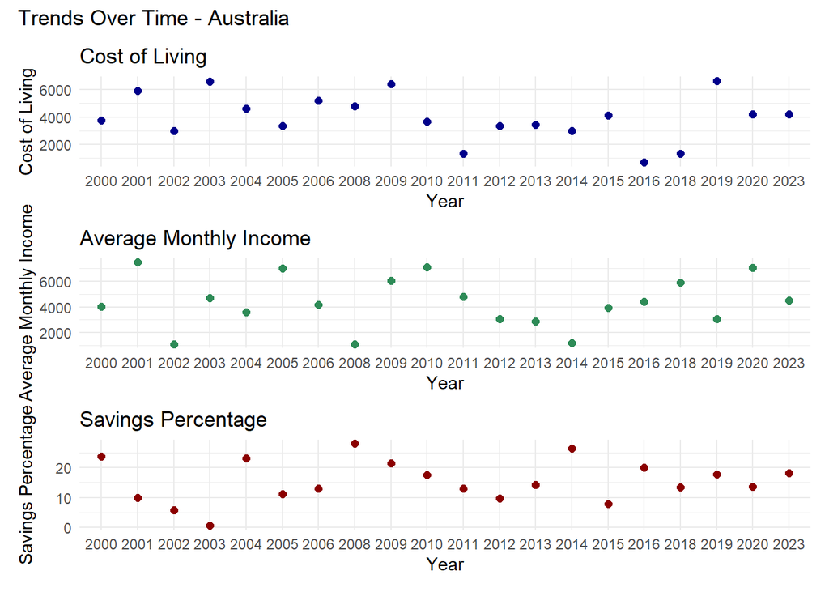

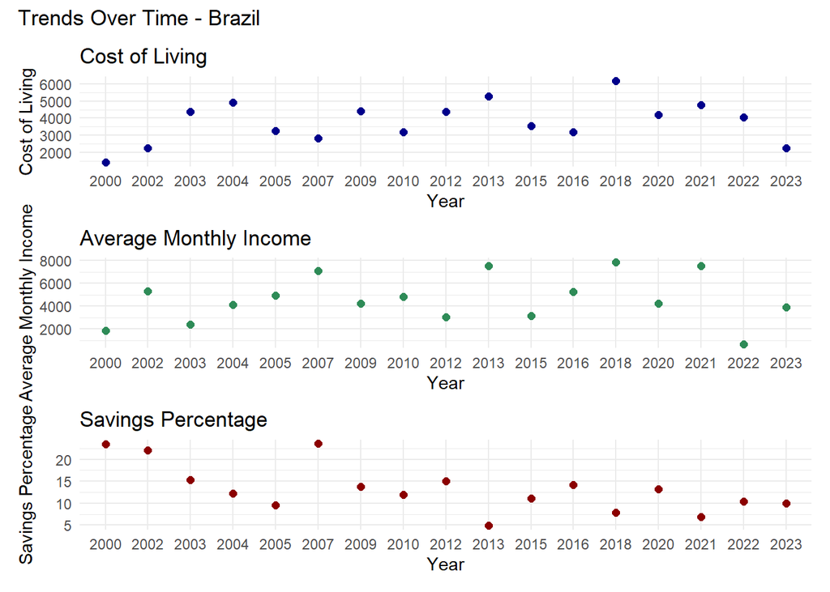

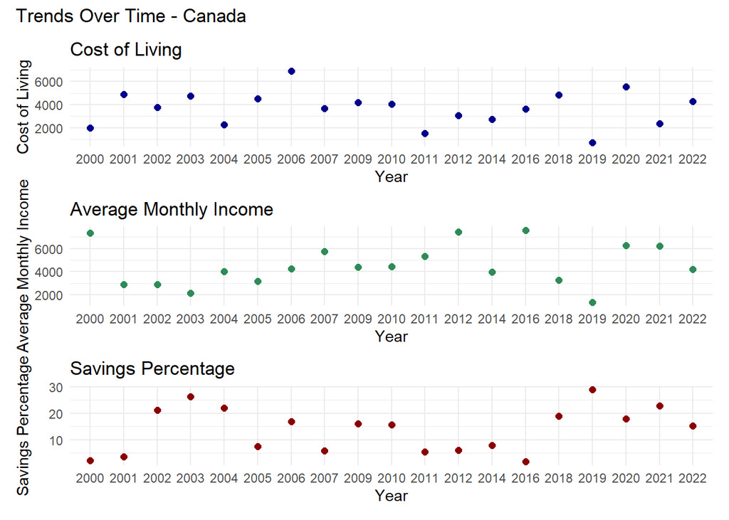

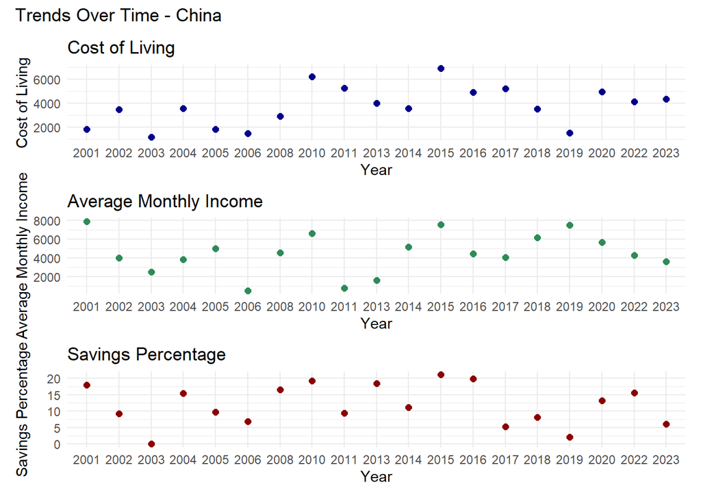

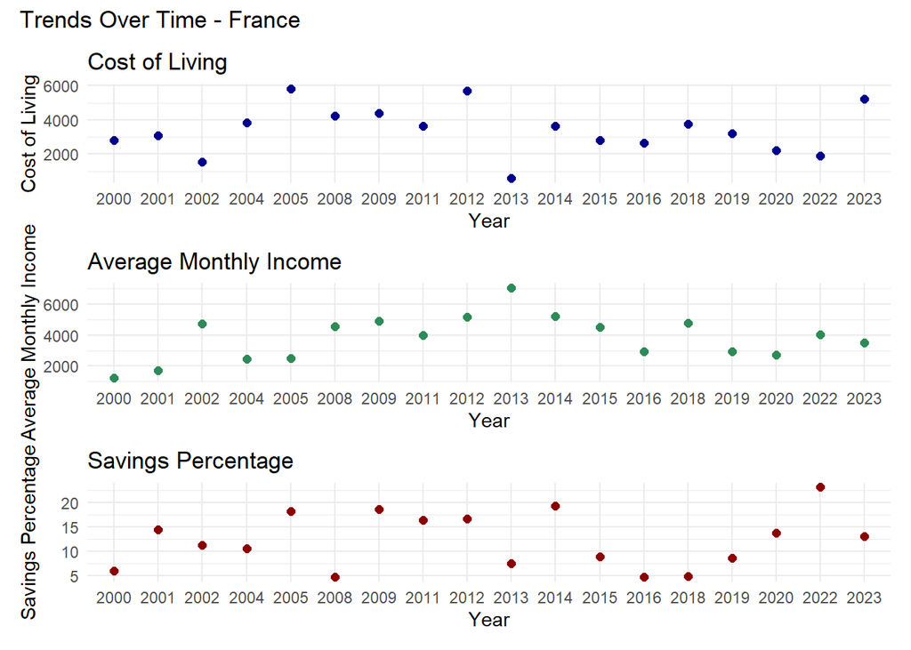

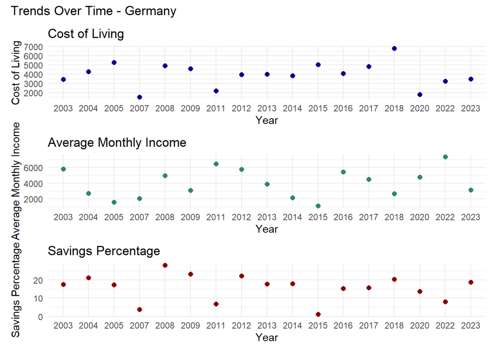

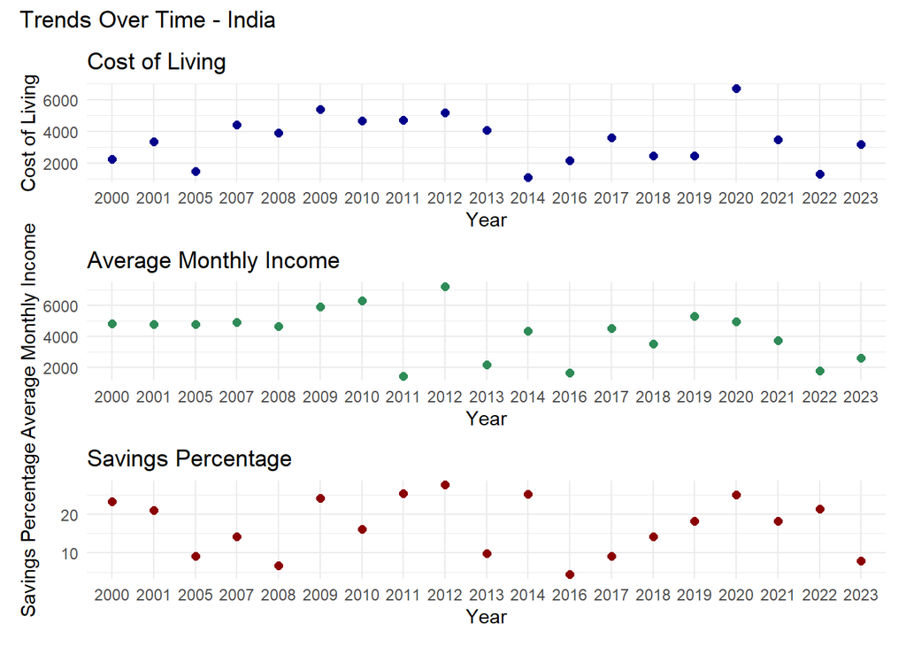

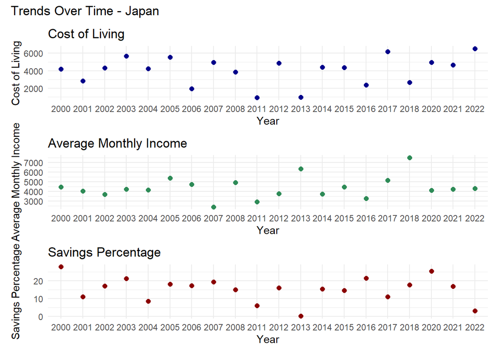

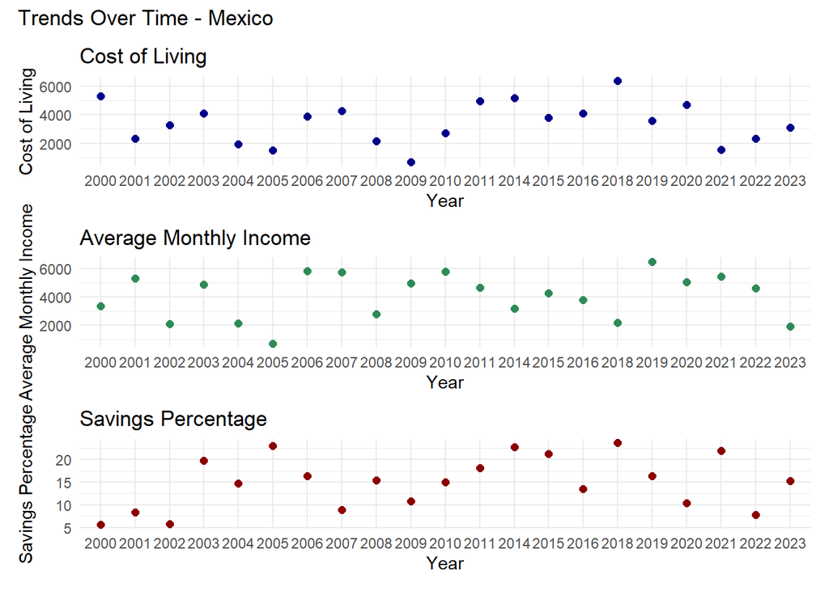

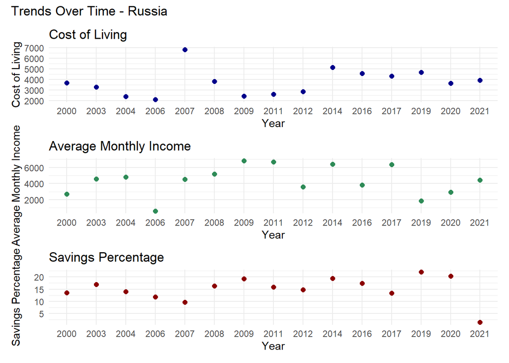

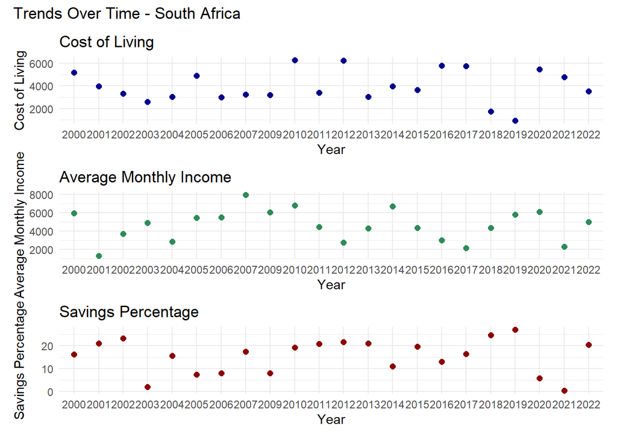

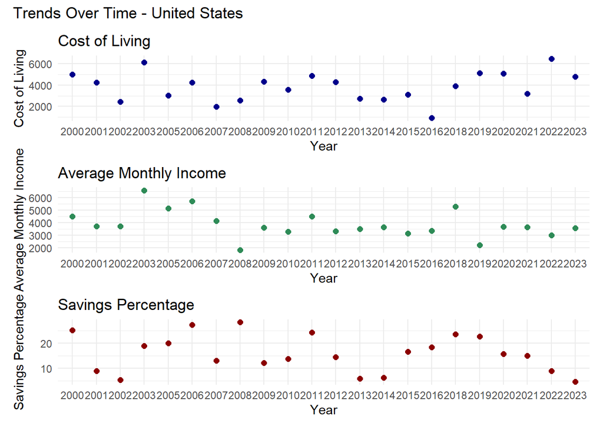

```r
# List of countries
countries <- unique(countryCOL_summary$country)

# Loop to create stacked plots per country
for (c in countries) {

  country_data <- countryCOL_summary %>% filter(country == c)

  plot_col <- ggplot(country_data, aes(x = year, y = cost_of_living)) +
    #geom_line(color = "blue", size = 1) +
    geom_point(color = "darkblue", size = 2) +
    labs(title = "Cost of Living", x = "Year", y = "Cost of Living") +
    theme_minimal()

  plot_income <- ggplot(country_data, aes(x = year, y = average_monthly_income)) +
    #geom_line(color = "green", size = 1) +
    geom_point(color = "seagreen", size = 2) +
    labs(title = "Average Monthly Income", x = "Year", y = "Average Monthly Income") +
    theme_minimal()

  plot_savings <- ggplot(country_data, aes(x = year, y = savings_percentage)) +
    #geom_line(color = "red", size = 1) +
    geom_point(color = "darkred", size = 2) +
    labs(title = "Savings Percentage", x = "Year", y = "Savings Percentage") +
    theme_minimal()

  combined_plot <- plot_col / plot_income / plot_savings +
    plot_annotation(title = paste("Trends Over Time -", c))

  print(combined_plot)
}
```

While for some countries, there seems to be a pattern in the trends of these three variables, it is hard to tell and it doesn’t seem to hold true for all the countries. More concrete analysis will help us determine if there truly is a pattern, which is what we’ll do next.

## Analysis

### Question 4: Are countries with lower costs of living characterized by higher savings percentages and average monthly incomes?

While we were able to answer questions 1 through 3 with just EDA, question 4 needs a little more. We have gotten some information from our EDA on this question, but let’s see if we can take it a bit further with some analysis methods.

```r
# Correlating cost_of_living with savings_percentage
cor_savings <- cor(countryCOL_summary$cost_of_living, countryCOL_summary$savings_percentage, use = "complete.obs")

# Correlating cost_of_living with average_monthly_income
cor_income <- cor(countryCOL_summary$cost_of_living, countryCOL_summary$average_monthly_income, use = "complete.obs")

cor_savings
```

```
[1] 0.1095306
```

```r
cor_income
```

```
[1] 0.01307461
```

These results confirm what was hinted at in our EDA plot for this question. There is a small positive correlation between Cost of Living and Savings Percentage but almost on correlation with average monthly income. Since we found that lower cost of living countries are not consistently characterized by higher savings or average monthly income, it must be more contingent on another factor or perhaps just individual behaviors when it comes to spending, saving, and working. This could also be related to tax rates which we are yet to analyze, as both the income effect and substitution effect both play a key role in influencing an individual’s behavior towards working. Before we shift focus to tax rates, let’s make a plot displaying our small positive correlation.

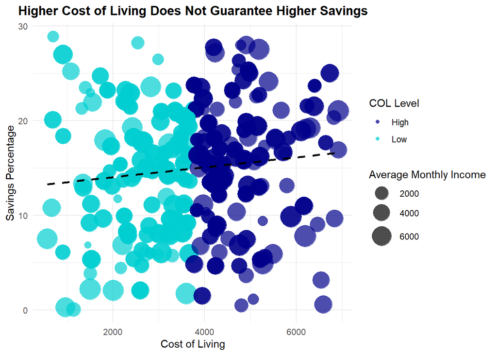

```r
bubble_plot <- ggplot(countryCOL_summary,
                      aes(x = cost_of_living,
                          y = savings_percentage,
                          size = average_monthly_income,
                          color = level)) +
  geom_point(alpha = 0.7) +
  geom_smooth(method = "lm", se = FALSE, color = "black", linetype = "dashed", show.legend = FALSE) +
  scale_size_continuous(range = c(3, 10)) +
  scale_color_manual(values = c("High" = "darkblue", "Low" = "darkturquoise")) +
  labs(
    title = "Higher Cost of Living Does Not Guarantee Higher Savings",
    x = "Cost of Living",
    y = "Savings Percentage",
    size = "Average Monthly Income",
    color = "COL Level"
  ) +
  theme_minimal() +
  theme(
    plot.title = element_text(face = "bold", hjust = 0.5)
  )

bubble_plot
```

```r
ggsave("bubble_plot_savings_vs_COL.pdf")
```

As you can see, there seem to be a few more points in the lower left corner arnd the upper right corner, hinting that in higher `cost_of_living` countries, people save a bit more and vice versa in lower `cost_of_living` countries. While there is only a small correlation, perhaps people find it more important to save well in high `COL` countries since unplanned expenses or emergencies can wrack up quite a bill. In contrast, such surprises may not break the bank as drastically in low `COL` countries.

### Question 5: Are countries with lower costs of living also characterized by lower or higher tax rates? And are tax rates responsible for the variation in average monthly income and savings percentages unexplained by cost of living alone?

We saw earlier that some countries are favorable from a tax standpoint but not from a cost of living standpoint and vice versa. In contrast, there were a few other countries we identified that had somewhat favorable values for both. But, is there a general pattern? Let’s run a correlation to see. While we’re exploring how taxes play a role in all of this, let’s also see if tax rates influence average monthly income and savings percentages. Previously, we thought cost of living drove these metrics, but we found very weak correlations. Perhaps, tax rates play a bigger role in this part of the puzzle.

```r
# Making sure there are no missing values in cost_of_living or tax_rate.
tax_data <- countryCOL_summary %>%
  drop_na(cost_of_living, tax_rate)

# Checking if cost of living correlates to tax rates.
cor_COL_tax <- cor(tax_data$cost_of_living, tax_data$tax_rate, use = "complete.obs")

# Checking if tax rate correlates to savings percentage.
cor_tax_savings <- cor(countryCOL_summary$tax_rate, countryCOL_summary$savings_percentage, use = "complete.obs")

# Checking if tax rate correlates to average monthly income.
cor_tax_income <- cor(countryCOL_summary$tax_rate, countryCOL_summary$average_monthly_income, use = "complete.obs")

cor_COL_tax
```

```
[1] 0.05356275
```

```r
cor_tax_savings
```

```
[1] -0.02292088
```

```r
cor_tax_income
```

```
[1] 0.06404004
```

There is almost no relationship between these variable pairs. The first is just barely an extremely weak correlation showing that as `cost_of_living` increases, `tax_rate` goes up slightly. For the second, a slight negative correlation with an increase in `tax_rate` corresponding to a slight decrease in `saving_percentage`. The third is the strongest of the three, though still extremely weak, showing that as `tax_rate` increases, `average_monthly_income` increases a little. This follows the **income effect of tax accounting** which is when an individual work’s extra to make up for the money lost to taxes and make ends meet. In contrast, **the substitution effect** decreases an individual’s willingness to work as the larger tax burden discourages employees to put in more hours of work and instead take more time off from work for leisure.

While we’ve already seen that there is hardly any correlation between tax rate and cost of living, let’s run a linear regression model just to confirm what correlation analysis suggested.

```r
model_tax <- lm(tax_rate ~ cost_of_living, data = tax_data)
summary(model_tax)
```

```
Call:
lm(formula = tax_rate ~ cost_of_living, data = tax_data)

Residuals:
     Min       1Q   Median       3Q      Max
-17.9809  -7.7665   0.0579   8.6982  17.7375

Coefficients:
                Estimate Std. Error t value Pr(>|t|)
(Intercept)    2.084e+01  1.379e+00  15.109   <2e-16 ***
cost_of_living 4.202e-04  3.510e-04   1.197    0.232
---
Signif. codes:  0 '***' 0.001 '**' 0.01 '*' 0.05 '.' 0.1 ' ' 1

Residual standard error: 10.02 on 498 degrees of freedom
Multiple R-squared:  0.002869,  Adjusted R-squared:  0.0008667
F-statistic: 1.433 on 1 and 498 DF,  p-value: 0.2319
```

Based on this, our linear equation is `tax_rate = 0.0004202 * cost_of_living + 20.84`. The slope is almost flat, and for every one unit increase in `cost_of_living`, the `tax_rate` goes up by `0.0004202`. The `p-value` of `0.2319` is above `alpha = 0.05` so it isn’t statistically significant. The `R2` of `0.002869` means that the model only explains about `0.29%` of the variation in tax rates. Essentially, our model doesn’t have very great predictive value here since these variables aren’t well-correlated.

Now, let’s visualize this in a heatmap that shows the correlation values for all combinations of the variables we’ve been trying to find relationships between. Namely, `cost_of_living`, `savings_percentage`, `average_monthly_income`, and `tax_rate`.

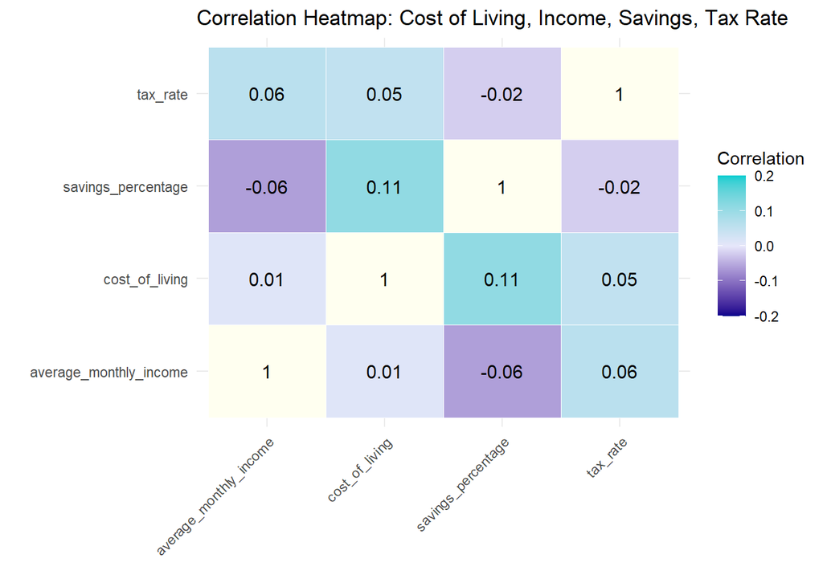

```r
# First, we need to select variables for our heatmap
heatmap_data <- tax_data %>%
  select(cost_of_living, savings_percentage, average_monthly_income, tax_rate)

# Now we have to compute the correlation matrix. We can nest the cor function within the round function so that we ensure that correlation values are rounded to two decimal places.
cor_matrix <- round(cor(heatmap_data, use = "complete.obs"), 2)

# Now, we need to convert the data to long format so that we can create the heatmap properly.
cor_long <- cor_matrix %>%
  as_tibble(rownames = "Var1") %>%
  pivot_longer(-Var1, names_to = "Var2", values_to = "Correlation")

# Now, let's plot the heatmap
heatmap_plot <- ggplot(cor_long, aes(x = Var1, y = Var2, fill = Correlation)) +
  geom_tile(color = "white") +
  scale_fill_gradient2(low = "darkblue", mid = "lavender", high = "darkturquoise", midpoint = 0, limits = c(-0.2, 0.2), na.value = "ivory") +
  geom_text(aes(label = Correlation), color = "black", size = 4) +
  labs(title = "Correlation Heatmap: Cost of Living, Income, Savings, Tax Rate",
       x = "", y = "") +
  theme_minimal() +
  theme(axis.text.x = element_text(angle = 45, hjust = 1))

heatmap_plot
```

```r
ggsave("correlation_heatmap.pdf")
```

Here we can clearly see that `savings_percentage` and `cost_of_living` have a correlation of `0.11` which is pretty weak, but of all the variable pairs we tested, this shows the strongest correlation. We can also see that `savings_percentage` and `tax_rate`, as we noted earlier, have very little correlation.

To show this further, let’s create a linear model relating `savings_percentage` and `tax_rate`.

```r
model_tax_savings <- lm(savings_percentage ~ tax_rate, data = tax_data)
summary(model_tax_savings)
```

```
Call:
lm(formula = savings_percentage ~ tax_rate, data = tax_data)

Residuals:
     Min       1Q   Median       3Q      Max
-15.0616  -5.1187   0.5027   4.4940  13.7839

Coefficients:
            Estimate Std. Error t value Pr(>|t|)
(Intercept) 15.24024    0.67046  22.731   <2e-16 ***
tax_rate    -0.01398    0.02732  -0.512    0.609
---
Signif. codes:  0 '***' 0.001 '**' 0.01 '*' 0.05 '.' 0.1 ' ' 1

Residual standard error: 6.119 on 498 degrees of freedom
Multiple R-squared:  0.0005254, Adjusted R-squared:  -0.001482
F-statistic: 0.2618 on 1 and 498 DF,  p-value: 0.6091
```

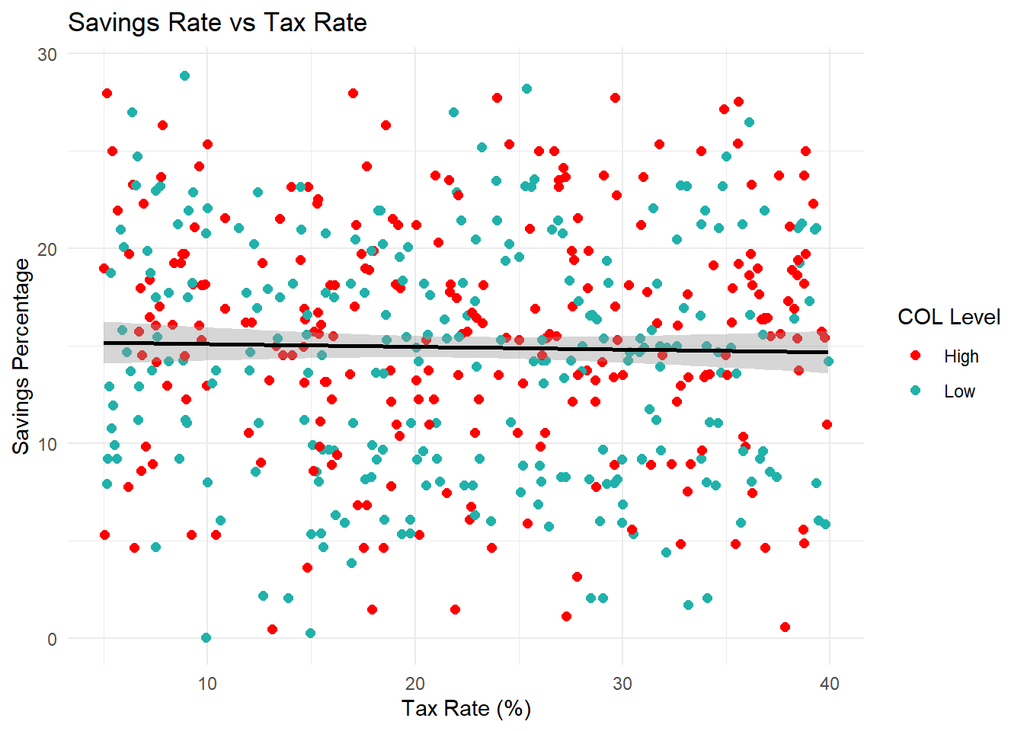

```r
ggplot(countryCOL_summary, aes(x = tax_rate, y = savings_percentage, color = level)) +
  geom_point(size = 2) +
  geom_smooth(method = "lm", se = TRUE, color = "black") +
  scale_color_manual(values = c("High" = "red", "Low" = "lightseagreen")) +
  labs(
    title = "Savings Rate vs Tax Rate",
    x = "Tax Rate (%)",
    y = "Savings Percentage",
    color = "COL Level"
  ) +
  theme_minimal()
```

```r
ggsave("savings_rate_vs_tax_rate.pdf")
```

As expected from our prior results, the regression line has little success in accurately expressing `savings_percentage` in terms of `tax_rate`.

### Question 6: What contributes greatest to a country’s cost of living? Is it healthcare, education, transportation, or housing? Or are they all roughly equal?

Now let’s see what drives a country’s cost of living up or down. Usually, housing markets largely impact cost of living. Let’s see if that is the case in this dataset as well.

```r
# let's get all of the components first
components <- countryCOL_summary %>%
  select(cost_of_living, housing_cost_percentage, transportation_cost_percentage,
         healthcare_cost_percentage, education_cost_percentage)

# now we'll make the correlation matrix
cor_matrix <- round(cor(components, use = "complete.obs"), 2)

# Now we have to convert the data to long format for plotting
cor_long <- cor_matrix %>%
  as_tibble(rownames = "Var1") %>%
  pivot_longer(-Var1, names_to = "Var2", values_to = "Correlation")

# Just so we only keep correlations with cost_of_living rather than all combinations, let's filter the ones we want.
cor_long_col <- cor_long %>% filter(Var1 == "cost_of_living")
cor_long_col
```

```
# A tibble: 5 × 3
  Var1           Var2                           Correlation
  <chr>          <chr>                                <dbl>
1 cost_of_living cost_of_living                        1
2 cost_of_living housing_cost_percentage              -0.01
3 cost_of_living transportation_cost_percentage        0.13
4 cost_of_living healthcare_cost_percentage            0
5 cost_of_living education_cost_percentage            -0.03
```

Based on this output, we can see that `cost_of_living` is most influenced by the costs of **transportation** in a given `country`. Now let’s create a `linear regression model` to see if we can predict `cost_of_living` using all the other four `components`.

```r
model_col <- lm(cost_of_living ~ housing_cost_percentage + transportation_cost_percentage +
                healthcare_cost_percentage + education_cost_percentage,
                data = countryCOL_summary)

summary(model_col)
```

```
Call:
lm(formula = cost_of_living ~ housing_cost_percentage + transportation_cost_percentage +
    healthcare_cost_percentage + education_cost_percentage, data = countryCOL_summary)

Residuals:
    Min      1Q  Median      3Q     Max
-3192.7  -811.1    11.4   800.2  3441.6

Coefficients:
                                Estimate Std. Error t value Pr(>|t|)
(Intercept)                    3403.7704   336.2145  10.124  < 2e-16 ***
housing_cost_percentage          -2.4745     6.6125  -0.374  0.70840
transportation_cost_percentage   40.7934    13.5465   3.011  0.00273 **
healthcare_cost_percentage       -0.3246    13.3705  -0.024  0.98064
education_cost_percentage       -12.5958    15.1014  -0.834  0.40464
---
Signif. codes:  0 '***' 0.001 '**' 0.01 '*' 0.05 '.' 0.1 ' ' 1

Residual standard error: 1271 on 495 degrees of freedom
Multiple R-squared:  0.01901,   Adjusted R-squared:  0.01108
F-statistic: 2.398 on 4 and 495 DF,  p-value: 0.04934
```

Based on this, our linear equation is `cost_of_living = -2.47 * housing_cost_percentage + 40.79 * transportation_cost_percentage - 0.32 * healthcare_cost_percentage - 12.60 * education_cost_percentage + 3403.77`. Looking at the `R2` of `0.019`, we can see that this model only accounts for roughly `1.9%` of the variation in the data. So, in simple terms, it isn’t doing a great job of predicting cost of living using these components. Based on the `p-values`, only transportation is statistically significant since its value of `0.0027` is below the `alpha = 0.05` threshold.

Let’s plot the model to better understand these results.

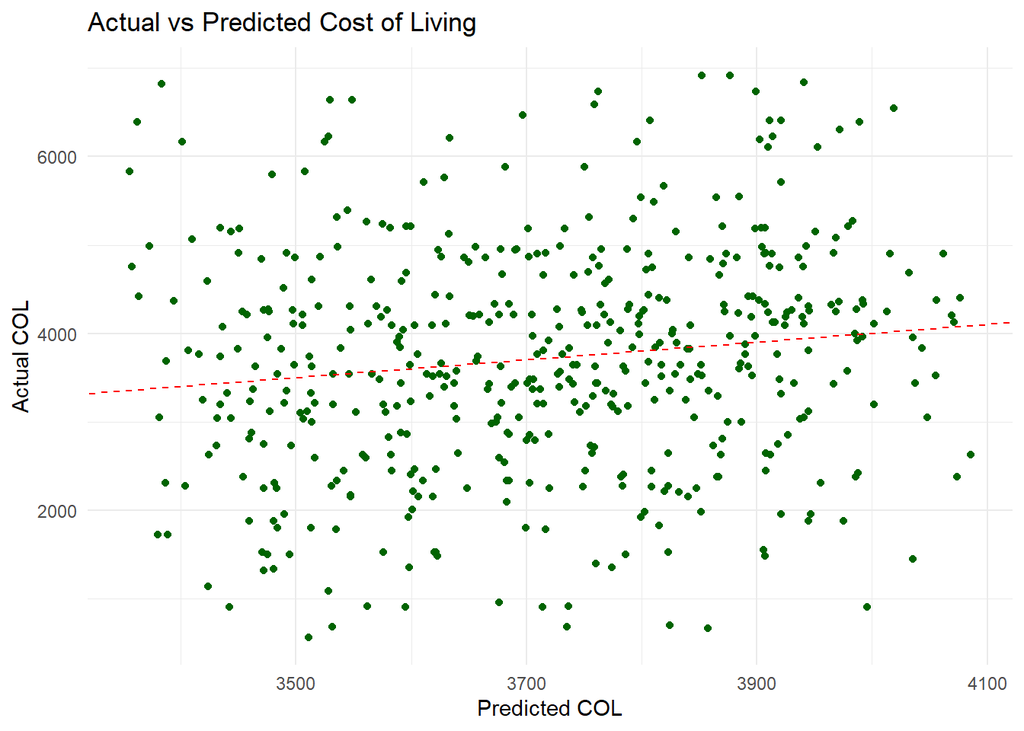

```r
model_col <- lm(cost_of_living ~ housing_cost_percentage + transportation_cost_percentage + healthcare_cost_percentage + education_cost_percentage,
                data = countryCOL_summary)

# We can predict values based on our model to see how well we do.
countryCOL_summary$predicted_COL <- predict(model_col)

# Now, we'll plot the actual vs predicted points
ggplot(countryCOL_summary, aes(x = predicted_COL, y = cost_of_living)) +
  geom_point(color = "darkgreen") +
  geom_abline(intercept = 0, slope = 1, linetype = "dashed", color = "red") +
  labs(
    title = "Actual vs Predicted Cost of Living",
    x = "Predicted COL",
    y = "Actual COL"
  ) +
  theme_minimal()
```

```r
ggsave("Actual_vs_Predicted_COL.pdf")
```

From this, we can more easily see that our model is a poor predictor of `cost_of_living`.

Now, let’s also create a pie chart to capture these insights. Before we do so, we need to save these coefficient values in a data frame as well as their corresponding components. Next, we have to create a variable that stores the absolute value of the coefficients so that we can create the pie chart properly. The percent variable specifies the sizes of the different pieces of the pie while the label allows us to include not only the component name, but also the coefficient value in the legend.

```r
coef_df <- data.frame(Component = c("Housing", "Transportation", "Healthcare", "Education"), Coefficient = c(-2.4745, 40.7934, -0.3246, -12.5958))

coef_df <- coef_df %>%
  mutate(Contribution = abs(Coefficient),
         Percent = Contribution / sum(Contribution) * 100,
         Label = paste0(Component, " (", round(Coefficient, 2), ")"))
coef_df
```

```
       Component Coefficient Contribution    Percent                  Label
1        Housing     -2.4745       2.4745  4.4039417        Housing (-2.47)
2 Transportation     40.7934      40.7934 72.6012355 Transportation (40.79)
3     Healthcare     -0.3246       0.3246  0.5777003     Healthcare (-0.32)
4      Education    -12.5958      12.5958 22.4171224      Education (-12.6)
```

Now, we can create the pie chart. For this, we will need `coord_polar( )` since we are trying to plot a circle.

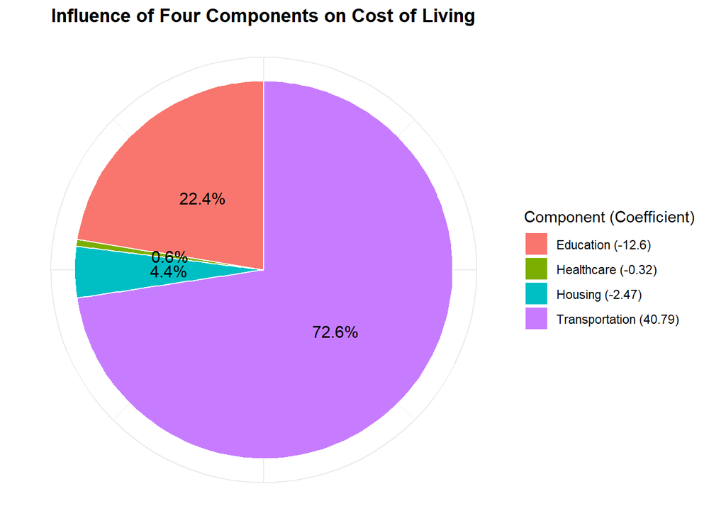

```r
ggplot(coef_df, aes(x = 1, y = Percent, fill = Label)) +
  geom_col(color = "white") +
  coord_polar(theta = "y") +
  geom_text(aes(label = paste0(round(Percent, 1), "%")),
            position = position_stack(vjust = 0.5), size = 4) +
  labs(title = "Influence of Four Components on Cost of Living",
       fill = "Component (Coefficient)") +
  theme_minimal() +
  theme(axis.title = element_blank(),
        axis.text = element_blank(),
        axis.ticks = element_blank(),
        plot.title = element_text(face = "bold", hjust = 0.5))
```

```r
ggsave("component_pie_chart.pdf")
```

Based on this, we can clearly see that `transportation` is the most influential, followed by `education`, `housing`, and `healthcare` in that order.

## Conclusion

Based on our analysis, cost of living is mainly influenced by transportation costs. While one would think that there would be a relationship between cost of living, tax rates, savings percentages, and average monthly income, many of our analyses showed weak correlations. However, there are some significant regional patterns, such as low cost of living in South Asia and Sub-Saharan Africa. Additionally, many countries that are favorable in terms of cost of living have been on a downward trend over the past few years, so if there is a particular country of interest to anyone, even if it doesn’t currently have a favorable cost of living, in the coming years, it might attain reasonable levels if the country is currently on a downward trend. While many of our questions did not find very clear patterns or relationships between variables, another similar analysis on more comprehensive data might yield clearer answers.